# Assignment 9: Visualization - Revealing a graph

*How to do it?*:

- Open the Rmarkdown file of this assignment (link) in Rstudio.
- Right under each **question**, insert a code chunk (you can use the hotkey `Ctrl + Alt + I` to add a code chunk) and code the solution for the question.
- `Knit` the rmarkdown file (hotkey: `Ctrl + Alt + K`) to export an html.
- Publish the html file to your Githiub Page.

*Submission*: Submit the link on Github of the assignment to Canvas

1. Use the dataset by of covid 19 by WHO at https://covid19.who.int/WHO-COVID-19-global-data.csv. Find the three countries with the most numbers of deaths by Covid-19.

Hint:

- Use `filter` to select the most current date
- Pipe with `arrange(-Cumulative_deaths)` to rank the data by the number of cumulative deaths
2. Make a plot revealing the number of deaths in the three countries with the most numbers of deaths
3. Create the new variable (column) `death_per_cases` recording the number of deaths per cases (Hint: divide cumulative deaths by cumulative cases). What are the three countries with the highest deaths per cases?
4. Make a plot revealing the number of deaths per cases of the US, Italy and Mexico.
5. Use `transition_reveal` to create three animated graph with the vaccination data at

https://raw.githubusercontent.com/govex/COVID-19/master/data_tables/vaccine_data/us_data/time_series/vaccine_data_us_timeline.csv

```r
library(ggplot2)
library(tidyverse)
library(gganimate)
library(gifski)
library(knitr)
library(lubridate)
```

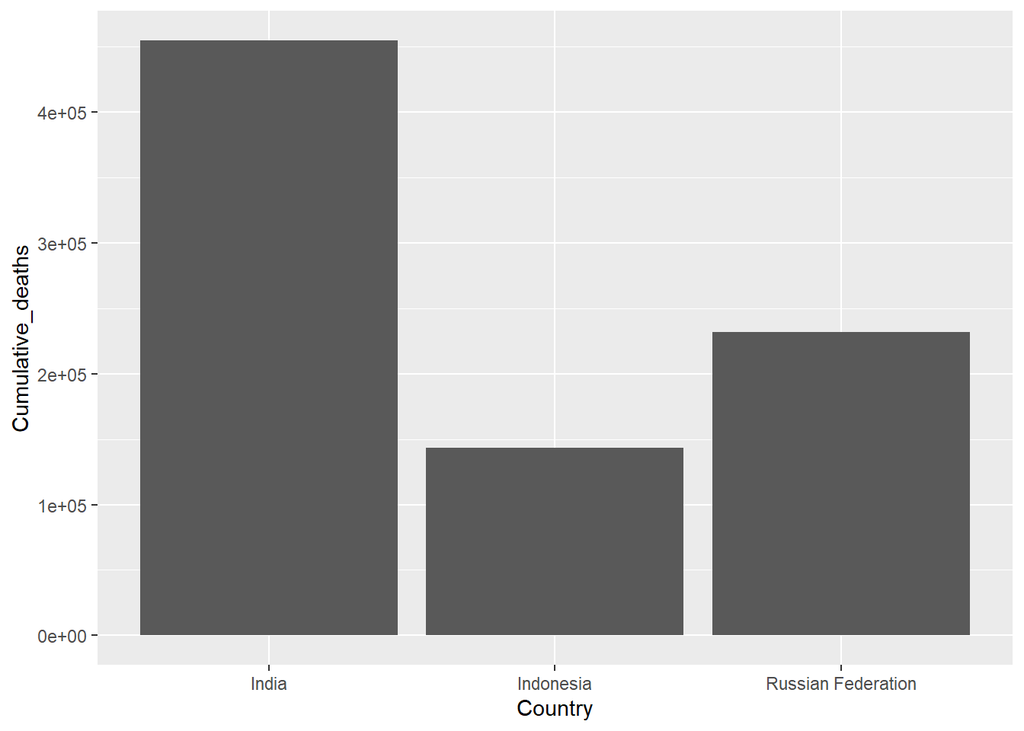

```r
#Find the three countries with the most numbers of deaths by Covid-19
df <- read_csv('https://covid19.who.int/WHO-COVID-19-global-data.csv')

df <- df %>% filter(df$Date_reported == '2021-10-25')

df %>% arrange(-Cumulative_deaths) %>%
mutate(rank=rank(-Cumulative_deaths)) %>%
filter(rank<=3) %>%
ggplot()+
geom_col(mapping=aes(x=Country, y=Cumulative_deaths))
```

[figure not shown]

```r
#Make a plot revealing the number of deaths in the three countries with the most numbers of deaths
df <- read_csv('https://covid19.who.int/WHO-COVID-19-global-data.csv')


df %>%
filter(Country %in% c('India','Indonesia','Russian Federation')) %>%
ggplot(aes(y=Cumulative_deaths,
            x=Date_reported,
            color=Country))+
  geom_line()+
  transition_reveal(Date_reported)
```

[output not shown]

[output cut: 126 more lines]

[output not shown]

[figure not shown]

```r
#Create the new variable (column) death_per_cases recording the number of deaths per cases (Hint: divide cumulative deaths by cumulative cases). What are the three countries with the highest deaths per cases?

df <- read_csv('https://covid19.who.int/WHO-COVID-19-global-data.csv')

df <- df %>% mutate(death_per_cases=Cumulative_deaths/Cumulative_cases)

df %>%
filter(Country %in% c('India','Indonesia','Russian Federation')) %>%
ggplot(aes(y=death_per_cases,
            x=Date_reported,
            color=Country))+
  geom_line()+
  transition_reveal(Date_reported)
```

[output not shown]

[output cut: 128 more lines]

[output not shown]

[figure not shown]

```r
#Make a plot revealing the number of deaths per cases of the US, Italy and Mexico

df <- read_csv('https://covid19.who.int/WHO-COVID-19-global-data.csv')

df <- df %>% mutate(death_per_cases=Cumulative_deaths/Cumulative_cases)

df %>%
filter(Country %in% c('United States of America','Mexico','Italy')) %>%
ggplot(aes(y=death_per_cases,
            x=Date_reported,
            color=Country))+
  geom_line()+
  transition_reveal(Date_reported)
```

[output not shown]

```r
#Use transition_reveal to create three animated graph with the vaccination data at https://raw.githubusercontent.com/govex/COVID-19/master/data_tables/vaccine_data/us_data/time_series/vaccine_data_us_timeline.csv

df <- read_csv('https://raw.githubusercontent.com/govex/COVID-19/master/data_tables/vaccine_data/us_data/time_series/vaccine_data_us_timeline.csv')


df %>%
ggplot(aes(y=Doses_shipped,
            x=Date,
            color=Country_Region))+
  geom_line()+
  transition_reveal(Date)
```

[output not shown]

[output not shown]

[output not shown]

[output cut: 70 more lines]

[output not shown]

```r
df %>%
ggplot(aes(y=Stage_One_Doses,
            x=Date,
            color=Country_Region))+
  geom_line()+
  transition_reveal(Date)
```

[output not shown]

[output not shown]

[output not shown]

[output cut: 82 more lines]

[output not shown]

[output not shown]

[output cut: 70 more lines]

[output not shown]

[figure not shown]

```r
df %>%
ggplot(aes(y=Stage_Two_Doses,
            x=Date,
            color=Country_Region))+
  geom_line()+
  transition_reveal(Date)
```